# 6.1. Data Visualisation

## Advanced plots: Violin plot

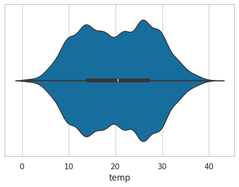

```python
sns.violinplot(data=bikes, x='temp');
```

## Advanced plots: Violin plot

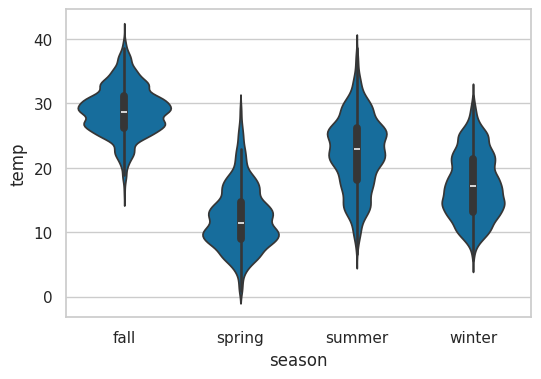

```python
sns.violinplot(data=bikes, y='temp', x='season');
```

### Preparing a two-way table for a heatmap

The next plot needs a table with **two categories × one value**: median rentals for every weekday × hour. Pure 5.2 - `groupby` with two keys, then `pivot` to a wide table (Dmitry builds it for his 3D plots, which are in the appendix):

```python
bikes_3D = bikes.groupby([bikes['datetime'].dt.weekday,bikes['datetime'].dt.hour]).agg({'count':'median'})
bikes_3D.index.names = ["weekday","hour"]
bikes_3D = bikes_3D.reset_index().pivot(index=['hour'],columns=['weekday'], values='count').astype(float)
bikes_3D.T
```

| hour weekday | 0 | 1 | 2 | 3 | 4 | 5 | 6 | 7 | 8 | 9 | ... | 14 | 15 | 16 | 17 | 18 | 19 | 20 | 21 | 22 | 23 |
| --- | --- | --- | --- | --- | --- | --- | --- | --- | --- | --- | --- | --- | --- | --- | --- | --- | --- | --- | --- | --- | --- |
| 0 | 30.0 | 13.0 | 8.0 | 4.0 | 5.0 | 23.0 | 94.0 | 268.0 | 417.0 | 219.0 | ... | 185.0 | 196.0 | 298.0 | 528.0 | 518.0 | 372.0 | 240.0 | 177.0 | 116.0 | 63.0 |
| 1 | 26.0 | 11.0 | 5.0 | 3.0 | 5.0 | 22.0 | 108.5 | 311.5 | 462.5 | 219.5 | ... | 159.0 | 178.0 | 292.0 | 569.0 | 538.0 | 365.0 | 268.0 | 195.0 | 137.0 | 73.0 |
| 2 | 33.0 | 12.0 | 5.0 | 4.0 | 4.0 | 27.0 | 112.0 | 312.0 | 487.0 | 225.0 | ... | 163.0 | 176.0 | 277.0 | 517.0 | 489.0 | 347.0 | 256.0 | 189.0 | 129.0 | 70.0 |
| 3 | 34.0 | 15.0 | 7.0 | 4.0 | 5.0 | 26.0 | 112.0 | 304.0 | 484.0 | 227.0 | ... | 180.0 | 180.0 | 294.0 | 563.0 | 523.0 | 364.0 | 258.0 | 195.0 | 149.0 | 97.0 |
| 4 | 54.5 | 23.0 | 11.0 | 6.0 | 5.0 | 24.0 | 87.5 | 248.0 | 454.0 | 244.5 | ... | 215.5 | 233.5 | 338.5 | 510.5 | 424.0 | 293.0 | 215.5 | 164.5 | 148.5 | 119.5 |
| 5 | 95.0 | 70.5 | 51.0 | 23.0 | 7.0 | 8.0 | 20.5 | 46.5 | 118.5 | 207.0 | ... | 389.0 | 393.5 | 399.0 | 347.0 | 297.0 | 248.0 | 181.5 | 165.0 | 146.5 | 124.0 |
| 6 | 99.5 | 77.5 | 66.0 | 28.0 | 9.5 | 8.0 | 15.0 | 34.5 | 87.0 | 169.0 | ... | 355.0 | 356.5 | 353.0 | 326.0 | 254.5 | 227.5 | 175.0 | 132.0 | 95.5 | 54.5 |

7 rows × 24 columns

## Advanced plots: Heatmap

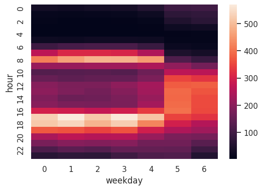

```python
sns.heatmap(bikes_3D);
```

Colour = value in each hour × weekday cell: two bright bands at 8 and 17-18 on weekdays 0-4 (Mon-Fri commute), one broad bright area around midday on 5-6 (weekend leisure). A heatmap shows a whole 7 × 24 table in one glance - and is far easier to read than the 3D surface of the same data in the appendix.

## Advanced plots: Heatmap for correlation matrix

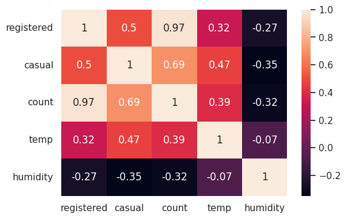

```python
sns.heatmap(bikes[['registered','casual','count','temp','humidity']].corr(), annot=True);
```

The **correlation matrix** from 5.1 as a heatmap, numbers written in (`annot=True`). Read it carefully: `count` vs `registered` = 0.97 is **not a discovery** - `count` is *defined* as `casual + registered`, so the correlation is there by construction; for the project choose columns that are not built from each other. The informative cells are the weather ones: `casual` riders show the strongest linear association with temperature (0.47), `registered` a weaker one (0.32); humidity is negative for both. "Strongest linear association" is the right wording - not "matters most": correlation measures one kind of relationship only (5.1).

## Advanced plots: Lines instead of Scatters

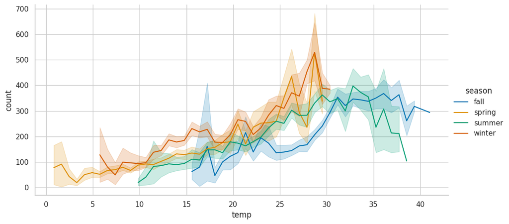

```python
sns.relplot(data = bikes.dropna(), x='temp', y='count', kind="line", hue="season", aspect=2);
```

`kind="line"` with many y values per x: seaborn draws the **mean** rentals per temperature value as a line and a shaded band that shows the **estimation uncertainty** of that mean, under the plotting method's assumptions (hourly observations of the same days and seasons are not independent, so the band is optimistic - read it as "roughly how sure", not as a statistical test). `dropna()` removes the test rows without `count`. Rentals grow with temperature up to about 30-35 °C and fall above - the scatter only hinted at that.

## Advanced plots: Linear regression

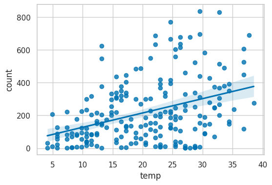

```python
bikes_sample = bikes.sample(300)
sns.regplot(data=bikes_sample, x='temp', y='count');
```

## Advanced plots: Linear regression

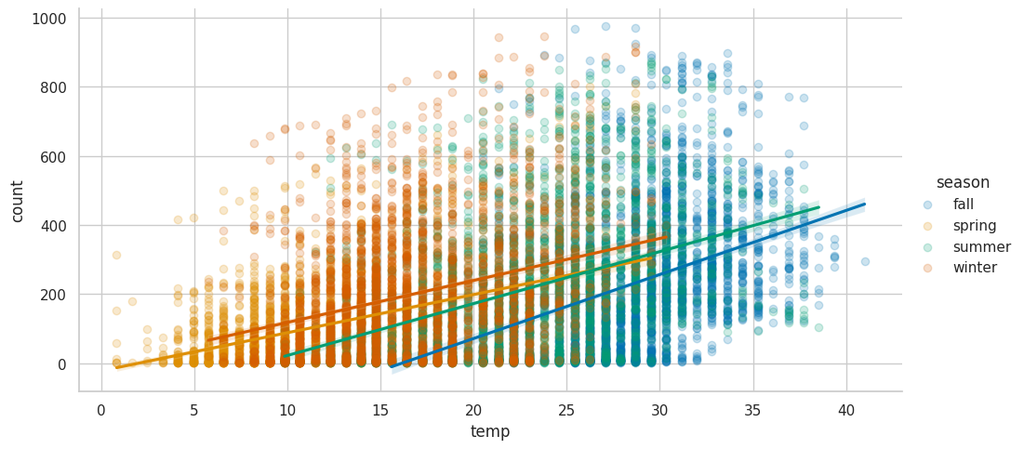

```python
sns.lmplot(data=bikes, x='temp', y='count', hue="season",aspect=2,  scatter_kws={'alpha':0.2});
```

## Advanced plots: Facet grid

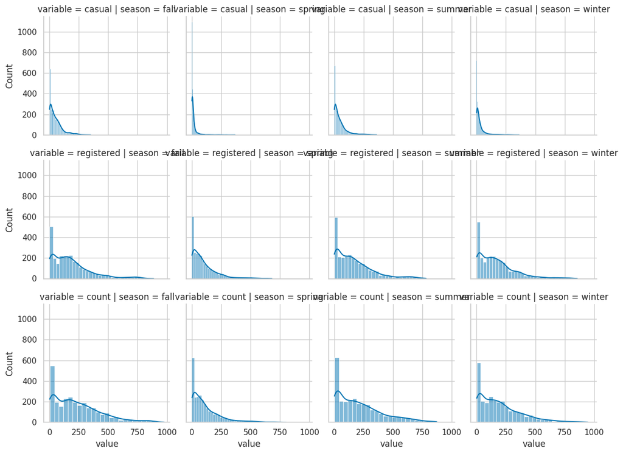

```python
bikes_long = bikes.melt(id_vars=['season'],value_vars=["casual","registered", "count"])
g = sns.FacetGrid(bikes_long, col='season', row='variable').map(sns.histplot, 'value', kde=True)
```

Rows: casual riders peak at very small numbers in every season; registered and total rentals spread much further. (`g` is a FacetGrid: titles for all panels at once with `g.set_titles(...)`, axis labels with `g.set_axis_labels(...)`.)

## Summary

- choose the plot from the **question**: distribution → histogram / density / box; relationship → scatter (+ regression); categories → bar (pie only for shares of a whole); time → line / area; two categories × value → heatmap
- **data first**: fix the dtypes (`category`, `datetime`), know how many rows a chart uses and what was dropped (`NaN`) - `bikes_known` vs `bikes`
- **pandas**: `s.plot.hist(bins=)`, `df.plot.box()`, `df.plot.scatter(x=, y=, alpha=)`, `groupby().agg().plot.bar()`, `set_index("datetime")[col].plot.line()`, `.plot.area()`
- **matplotlib**: `figure, axis = plt.subplots(rows, cols, figsize=, sharex=, sharey=)`; `axis[i]` / `axis.flatten()`; draw with `axis.scatter / hist / plot` or pandas `ax=axis[i]`; finish with `set_title`, `set_xlabel`, `set_ylabel` (units!), `legend`, `figure.tight_layout()`; bars start at 0
- **seaborn**: `sns.set(style=, palette="colorblind")`; `relplot(data=, x=, y=, hue=, kind=)` (figure-level → grid, `.set()`), `histplot(kde=True)`, `violinplot(x=category, y=value)`, `heatmap(table or corr(), annot=True)` (axes-level → Axes), `regplot` / `lmplot`
- **reading charts honestly**: correlation = linear association, not cause; `count = casual + registered` correlates by construction; bands show estimation uncertainty under assumptions
- for the **project**: explore with pandas, present with seaborn / a matplotlib grid, every figure = title + labelled axes + number of observations + one sentence of insight

# Thank you

### 3D plots

(The table `bikes_3D` - median rentals per weekday × hour - was built in the seaborn section.)

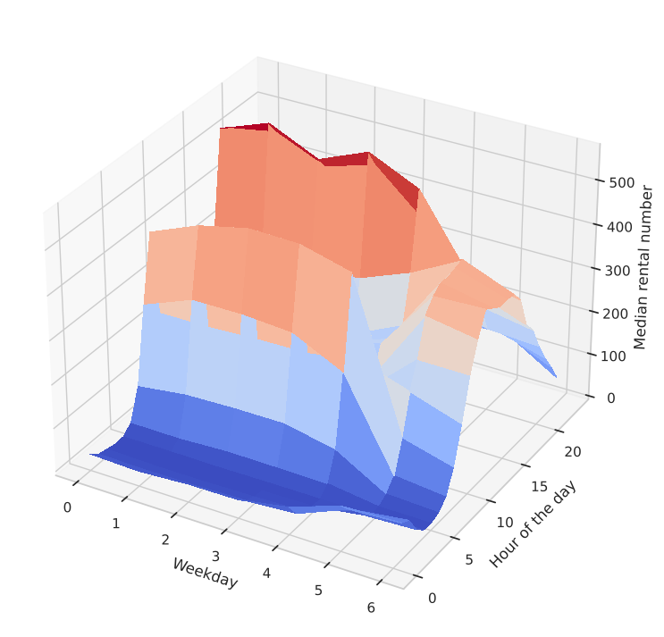

```python
figure, axis = plt.subplots(subplot_kw={"projection": "3d"},figsize=(9,9))
X, Y = np.meshgrid(bikes_3D.columns, bikes_3D.index)
surf = axis.plot_surface(X, Y, bikes_3D, cmap=plt.cm.coolwarm, linewidth=0, antialiased=False)
axis.set_ylabel("Hour of the day")
axis.set_xlabel("Weekday")
axis.set_zlabel("Median rental number")
plt.show()
```

### 3D plots: Formatter

```python
import calendar
list(calendar.day_abbr)
```

```
['Mon', 'Tue', 'Wed', 'Thu', 'Fri', 'Sat', 'Sun']
```

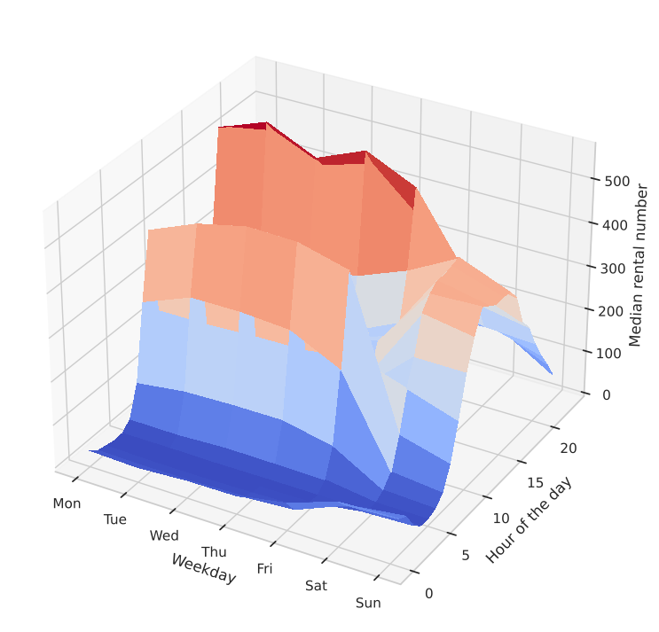

```python
def format_days(x, pos):
    if (int(x) in range(len(calendar.day_abbr))):
        return(calendar.day_abbr[int(x)])

figure, axis = plt.subplots(subplot_kw={"projection": "3d"},figsize=(9,9))
X, Y = np.meshgrid(bikes_3D.columns, bikes_3D.index)
surf = axis.plot_surface(X, Y, bikes_3D, cmap=plt.cm.coolwarm, linewidth=0, antialiased=False)
axis.set_ylabel("Hour of the day")
axis.set_xlabel("Weekday")
axis.xaxis.set_major_formatter(plt.FuncFormatter(format_days))
axis.set_zlabel("Median rental number")
plt.show()
```

The surface shows the weekly rhythm: two sharp ridges at 8 and 17-18 on Monday-Friday (commuting), one broad hump around midday on Saturday-Sunday (leisure). `format_days` is a function (week 3) that turns the weekday number 0-6 into "Mon" ... "Sun" for the tick labels. Impressive - but 3D plots are hard to read exactly; the seaborn heatmap of the same table in the main part is the version for a report.

### 3D plots: contours and heatmaps

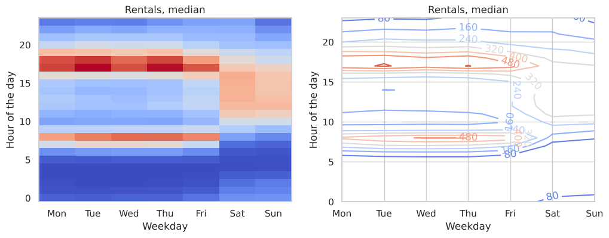

```python
figure, axis = plt.subplots(1,2, figsize=(12,4))
X, Y = np.meshgrid(bikes_3D.columns, bikes_3D.index)
axis[0].grid(False)
axis[0].pcolormesh(X, Y, bikes_3D, cmap=plt.cm.coolwarm)
axis[0].set_title("Rentals, median")
axis[0].set_ylabel("Hour of the day")
axis[0].set_xlabel("Weekday")
axis[0].xaxis.set_major_formatter(plt.FuncFormatter(format_days))
cs = axis[1].contour(X, Y, bikes_3D, cmap=plt.cm.coolwarm)
plt.clabel(cs, inline=1)
axis[1].set_title("Rentals, median")
axis[1].set_ylabel("Hour of the day")
axis[1].set_xlabel("Weekday")
axis[1].xaxis.set_major_formatter(plt.FuncFormatter(format_days))
plt.show()
```

A **heatmap** drawn with plain matplotlib (`pcolormesh`) and **contour lines** (lines of equal rentals, like heights on a map) - the same information as the 3D surface, flat and comparable. Rule of thumb: prefer the flat version; use 3D only when it adds something.